# Portfolio Analysis using Machine Learning and Predictive Analytics

Sriniwas M | Aditya S | Group V

28 December 2018

### Update R

```
install.packages("installr")
library(installr)
updateR()
```

### Load the Relevant Packages

```
library(lmtest)
library(rmarkdown)
library(knitr)
```

### Read the Data File and Define Variables

```r
NewData <- data.frame(read.csv("New Data.csv"))

# Foreign Institutional Investments during the month
FII <- NewData[,2]

#Month end IIP General Index
IIPG <- NewData[,7]

#1 period lagged value of IIP General Index
IIPGLag <- NewData[,8]

#Dow Jones Industrial Average for MOnth end
DJIA <- NewData[,9]

#Monthly return on DJIA
DJIAReturn <- NewData[,10]

#USD/INR exchange rate expressed as INR per USD
FXRate <- NewData[,11]

#Monthly change in USD/INR rate
FXRateChange <- NewData[,12]

#1 period lagged value of FX Rate change
FXRateChangeLag <- NewData[,24]

#Value of NIFTY Bank Index
NIFTYBank <- NewData[,13]

#Monthly return on NIFTY Bank Index
NIFTYBankReturn <- NewData[,14]

#M3 money supply (monthly)
M3 <- NewData[,21]

#Change in M3 money supply for each month
M3Change <- NewData[,22]

#1 period lagged value of Change in M3 money supply
M3ChangeLag <- NewData[,23]

#RBI Foreign Exchange Reserves (Month end in USD)
FER <- NewData[,25]

#Monthly change in RBI Foreign Exchange Reserves
FERChange <- NewData[,26]
```

### Scatter Plot and Correlation Analysis

**1. NIFTY Bank Return vs FII**

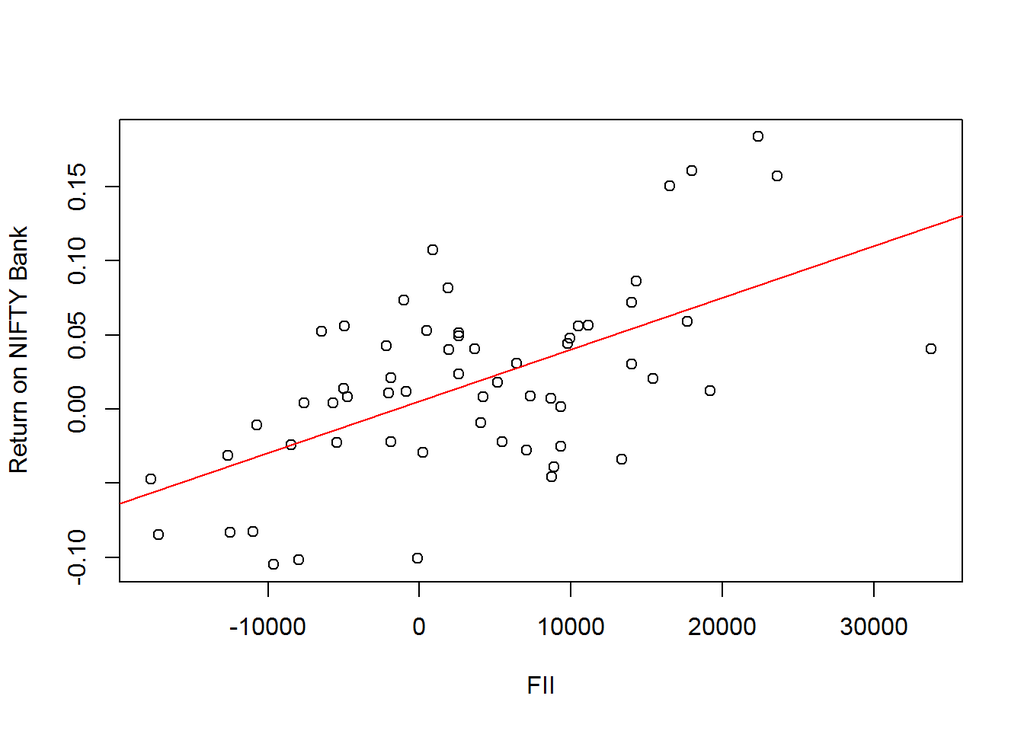

```r
plot(NIFTYBankReturn ~ FII, data=NewData, xlab="FII", ylab="Return on NIFTY Bank")
abline(lm(NIFTYBankReturn ~ FII), col="red")
```

```r
cor.test(NIFTYBankReturn, FII, method = "pearson")
```

```
##
##  Pearson's product-moment correlation
##
## data:  NIFTYBankReturn and FII
## t = 5.56, df = 58, p-value = 7.151e-07
## alternative hypothesis: true correlation is not equal to 0
## 95 percent confidence interval:
##  0.3948404 0.7337156
## sample estimates:
##       cor
## 0.5896472
```

*Positive* correlation between FII and Bank NIFTY returns

**2. NIFTY Bank Return vs Change in Foreign Exchange Reserves**

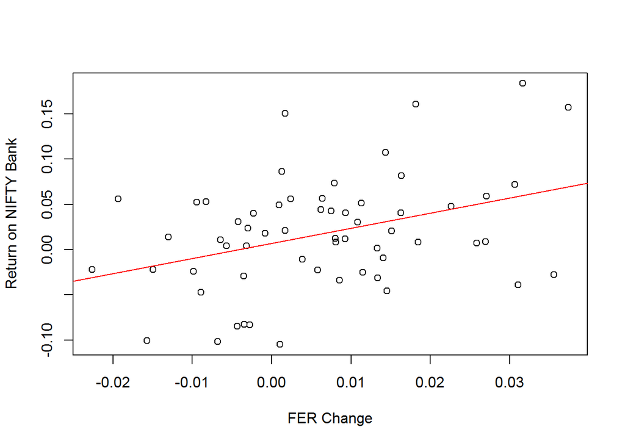

```r
plot(NIFTYBankReturn ~ FERChange, data=NewData, xlab="FER Change", ylab="Return on NIFTY Bank")
abline(lm(NIFTYBankReturn ~ FERChange), col="red")
```

```r
cor.test(NIFTYBankReturn, FERChange, method = "pearson")
```

```
##
##  Pearson's product-moment correlation
##
## data:  NIFTYBankReturn and FERChange
## t = 3.0453, df = 58, p-value = 0.003493
## alternative hypothesis: true correlation is not equal to 0
## 95 percent confidence interval:
##  0.1295804 0.5713469
## sample estimates:
##       cor
## 0.3712884
```

*Positive* correlation between change in FER and returns on Bank NIFTY

**3. NIFTY Bank Return vs Change in M3 Money supply**

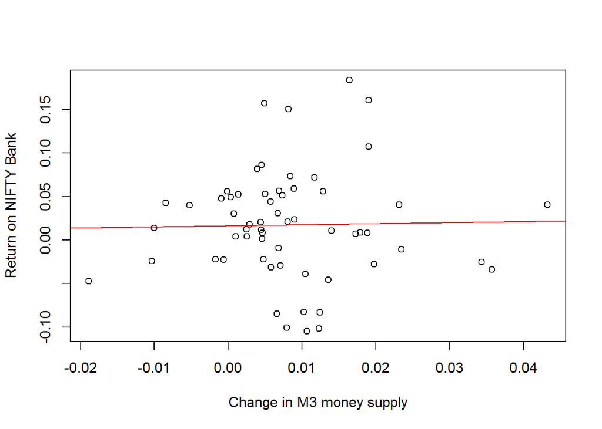

```r
plot(NIFTYBankReturn ~ M3Change, data=NewData, xlab="Change in M3 money supply", ylab="Return on NIFTY Bank")
abline(lm(NIFTYBankReturn ~ M3Change), col="red")
```

```r
cor.test(NIFTYBankReturn, M3Change, method = "pearson")
```

```
##
##  Pearson's product-moment correlation
##
## data:  NIFTYBankReturn and M3Change
## t = 0.15218, df = 58, p-value = 0.8796
## alternative hypothesis: true correlation is not equal to 0
## 95 percent confidence interval:
##  -0.2351391  0.2725207
## sample estimates:
##        cor
## 0.01997847
```

*No* correlation between Change in M3 money supply and Bank NIFTY returns

**4. NIFTY Bank Return vs 1 period lagged value of Change in M3 Money supply**

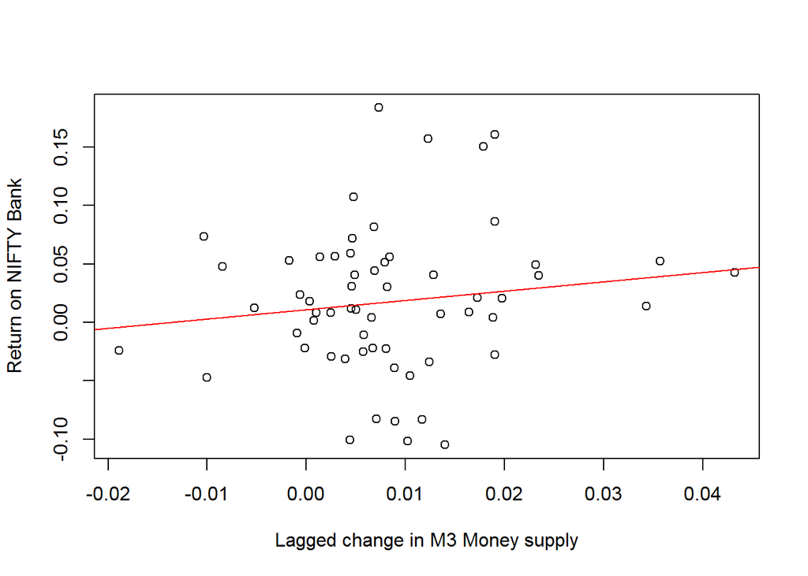

```r
plot(NIFTYBankReturn ~ M3ChangeLag, data=NewData, xlab="Lagged change in M3 Money supply", ylab="Return on NIFTY Bank")
abline(lm(NIFTYBankReturn ~ M3ChangeLag), col="red")
```

```r
cor.test(NIFTYBankReturn, M3ChangeLag, method = "pearson")
```

```
##
##  Pearson's product-moment correlation
##
## data:  NIFTYBankReturn and M3ChangeLag
## t = 1.0599, df = 58, p-value = 0.2936
## alternative hypothesis: true correlation is not equal to 0
## 95 percent confidence interval:
##  -0.1202983  0.3785136
## sample estimates:
##       cor
## 0.1378369
```

*No* significant correlation between Lagged change in M3 Money supply and Bank NIFTY returns

**5. NIFTY Bank Return vs DJIA return**

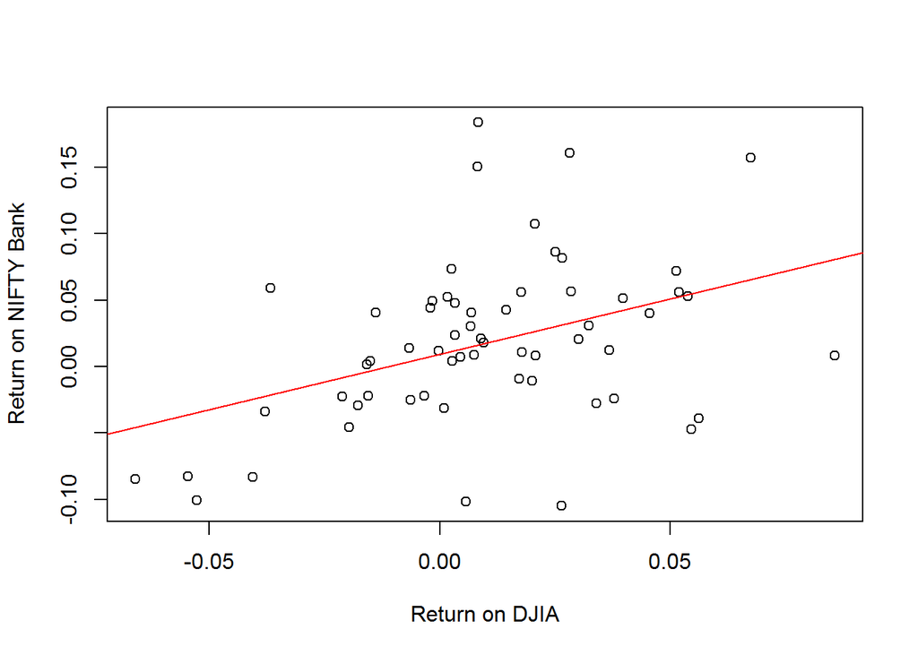

```r
plot(NIFTYBankReturn ~ DJIAReturn, data=NewData, xlab="Return on DJIA", ylab="Return on NIFTY Bank")
abline(lm(NIFTYBankReturn ~ DJIAReturn), col="red")
```

```r
cor.test(NIFTYBankReturn, DJIAReturn, method = "pearson")
```

```
##
##  Pearson's product-moment correlation
##
## data:  NIFTYBankReturn and DJIAReturn
## t = 3.3379, df = 58, p-value = 0.001479
## alternative hypothesis: true correlation is not equal to 0
## 95 percent confidence interval:
##  0.1642383 0.5947258
## sample estimates:
##       cor
## 0.4014221
```

*Positive* correlation between DJIA returns and Bank NIFTY returns

**6. NIFTY Bank Return vs Change in Fx rate (USD/INR)**

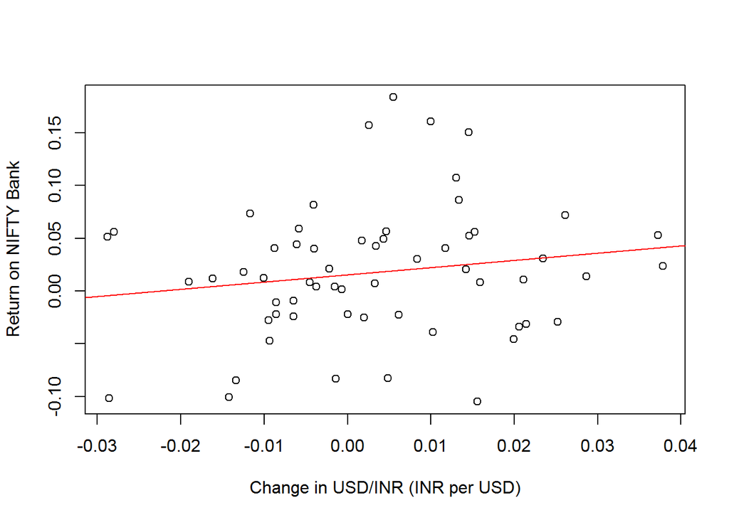

```r
plot(NIFTYBankReturn ~ FXRateChange, data=NewData, xlab="Change in USD/INR (INR per USD)", ylab="Return on NIFTY Bank")
abline(lm(NIFTYBankReturn ~ FXRateChange), col="red")
```

```r
cor.test(NIFTYBankReturn, FXRateChange, method = "pearson")
```

```
##
##  Pearson's product-moment correlation
##
## data:  NIFTYBankReturn and FXRateChange
## t = 1.2726, df = 58, p-value = 0.2082
## alternative hypothesis: true correlation is not equal to 0
## 95 percent confidence interval:
##  -0.09299986  0.40192086
## sample estimates:
##      cor
## 0.164817
```

*No* significant correlation between Change in USD/INR rate and Bank NIFTY returns

**7. NIFTY Bank Return vs 1 period lagged Change in Fx rate (USD/INR)**

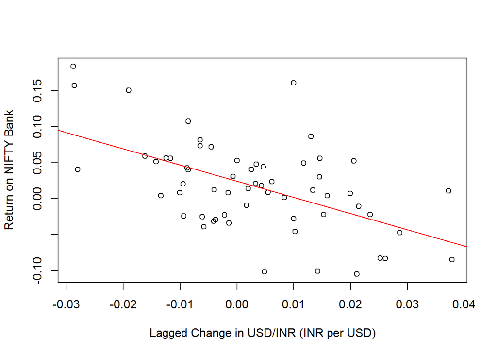

```r
plot(NIFTYBankReturn ~ FXRateChangeLag, data=NewData, xlab="Lagged Change in USD/INR (INR per USD)", ylab="Return on NIFTY Bank")
abline(lm(NIFTYBankReturn ~ FXRateChangeLag), col="red")
```

```r
cor.test(NIFTYBankReturn, FXRateChangeLag, method = "pearson")
```

```
##
##  Pearson's product-moment correlation
##
## data:  NIFTYBankReturn and FXRateChangeLag
## t = -4.9166, df = 58, p-value = 7.593e-06
## alternative hypothesis: true correlation is not equal to 0
## 95 percent confidence interval:
##  -0.6999059 -0.3345197
## sample estimates:
##        cor
## -0.5423737
```

*Negative* correlation between Lagged Change in USD/INR rate and Bank NIFTY returns

**8. NIFTY Bank Return vs IIP General Index**

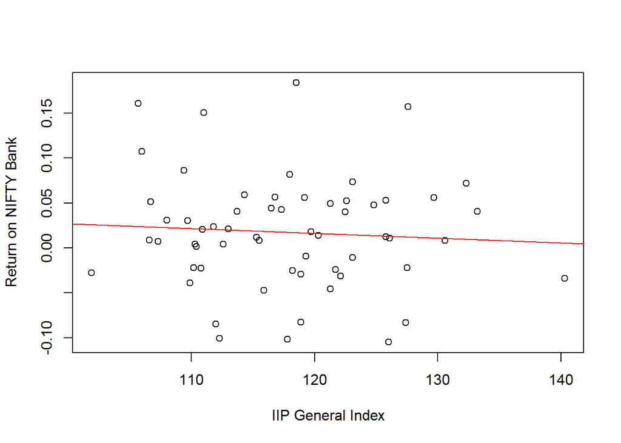

```r
plot(NIFTYBankReturn ~ IIPG, data=NewData, xlab="IIP General Index", ylab="Return on NIFTY Bank")
abline(lm(NIFTYBankReturn ~ IIPG), col="red")
```

```r
cor.test(NIFTYBankReturn, IIPG, method = "pearson")
```

```
##
##  Pearson's product-moment correlation
##
## data:  NIFTYBankReturn and IIPG
## t = -0.52426, df = 58, p-value = 0.6021
## alternative hypothesis: true correlation is not equal to 0
## 95 percent confidence interval:
##  -0.3170721  0.1885358
## sample estimates:
##         cor
## -0.06867675
```

*No* correlation between IIP General Index and Bank NIFTY returns

**9. NIFTY Bank Return vs 1 period lagged IIP General Index**

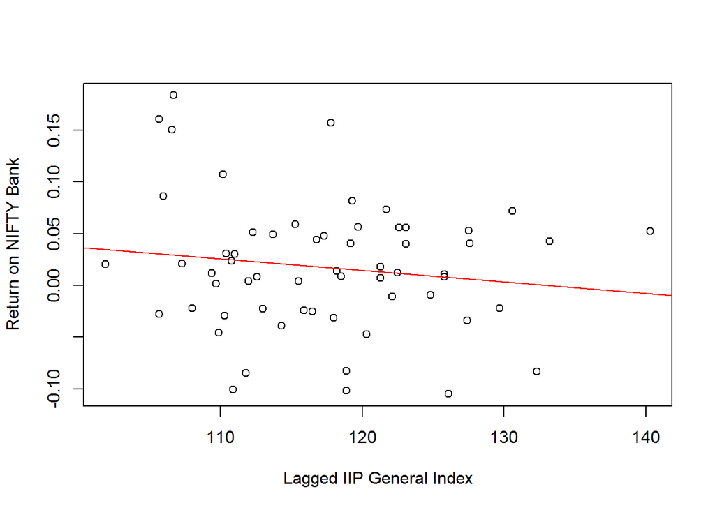

```r
plot(NIFTYBankReturn ~ IIPGLag, data=NewData, xlab="Lagged IIP General Index", ylab="Return on NIFTY Bank")
abline(lm(NIFTYBankReturn ~ IIPGLag), col="red")
```

```r
cor.test(NIFTYBankReturn, IIPGLag, method = "pearson")
```

```
##
##  Pearson's product-moment correlation
##
## data:  NIFTYBankReturn and IIPGLag
## t = -1.1108, df = 58, p-value = 0.2712
## alternative hypothesis: true correlation is not equal to 0
## 95 percent confidence interval:
##  -0.3841768  0.1137620
## sample estimates:
##       cor
## -0.144332
```

*No* correlation between IIP General Index and Bank NIFTY returns

### Multiple Regression Analysis

**Multiple Regression with All Independent Variables**

```r
Fit1 <- lm(NIFTYBankReturn ~ FII + FERChange + M3ChangeLag + DJIAReturn + FXRateChangeLag + IIPGLag, data = NewData)
summary(Fit1)
```

```
##
## Call:
## lm(formula = NIFTYBankReturn ~ FII + FERChange + M3ChangeLag +
##     DJIAReturn + FXRateChangeLag + IIPGLag, data = NewData)
##
## Residuals:
##       Min        1Q    Median        3Q       Max
## -0.099294 -0.022496 -0.000043  0.022574  0.097612
##
## Coefficients:
##                   Estimate Std. Error t value Pr(>|t|)
## (Intercept)      2.463e-02  9.463e-02   0.260  0.79566
## FII              2.386e-06  8.043e-07   2.967  0.00451 **
## FERChange       -2.323e-01  5.543e-01  -0.419  0.67692
## M3ChangeLag      8.250e-01  5.820e-01   1.418  0.16218
## DJIAReturn       5.535e-01  2.189e-01   2.529  0.01445 *
## FXRateChangeLag -1.047e+00  5.220e-01  -2.005  0.05003 .
## IIPGLag         -1.975e-04  8.024e-04  -0.246  0.80656
## ---
## Signif. codes:  0 '***' 0.001 '**' 0.01 '*' 0.05 '.' 0.1 ' ' 1
##
## Residual standard error: 0.04711 on 53 degrees of freedom
## Multiple R-squared:  0.4859, Adjusted R-squared:  0.4277
## F-statistic: 8.348 on 6 and 53 DF,  p-value: 2.202e-06
```

**Multiple Regression after Dropping the Insignificant Variables**

```r
Fit2 <- lm(NIFTYBankReturn ~ FII + FXRateChangeLag + DJIAReturn, data = NewData)
summary(Fit2)
```

```
##
## Call:
## lm(formula = NIFTYBankReturn ~ FII + FXRateChangeLag + DJIAReturn,
##     data = NewData)
##
## Residuals:
##       Min        1Q    Median        3Q       Max
## -0.101438 -0.021182 -0.002027  0.023763  0.105935
##
## Coefficients:
##                   Estimate Std. Error t value Pr(>|t|)
## (Intercept)      7.052e-03  7.365e-03   0.958  0.34240
## FII              2.402e-06  7.053e-07   3.406  0.00123 **
## FXRateChangeLag -9.697e-01  5.089e-01  -1.905  0.06186 .
## DJIAReturn       5.100e-01  2.134e-01   2.390  0.02025 *
## ---
## Signif. codes:  0 '***' 0.001 '**' 0.01 '*' 0.05 '.' 0.1 ' ' 1
##
## Residual standard error: 0.04675 on 56 degrees of freedom
## Multiple R-squared:  0.4649, Adjusted R-squared:  0.4363
## F-statistic: 16.22 on 3 and 56 DF,  p-value: 1.046e-07
```